# Latihan Pertemuan 4

Vita Rizkyana Anggraeni_G1401211065

2023-09-21

## White Noise

Pembangkitan data berpola AR, MA, ARMA, dan banyak proses deret waktu lainnya diawali pembangkitan *white noise*. *White noise* merupakan sederet nilai dari peubah bebas stokastik identik. Oleh karena itu, *white noise* memiliki dua karakteristik penting:

1. *White noise* tidak memiliki autokorelasi (**karena saling bebas**)
2. Nilai harapan dan ragam *white noise* sama (**karena berasal dari peubah acak bebas stokastik identik**)

*White noise* dibangkitkan dari suatu peubah acak, umumnya peubah acak normal.

```r
set.seed(1065)
wn <- rnorm(300)
wn
```

```
##   [1]  0.454317297 -0.304632499 -0.734757228 -0.122323441  0.731740819
##   [6] -1.623224299  0.826390685  1.698645857  0.994715613 -0.874431880
##  [11] -0.563635003 -0.808897259  0.118289577  1.092697864  1.245800597
##  [16] -0.320562263  0.816445184  0.074428479 -2.456736873 -1.464937818
##  [21]  1.453253439 -1.480882148  0.983622308  1.220264356  0.354770852
##  [26] -0.707833900 -0.102007030 -0.414629864 -0.414176382  1.058057081
##  [31] -0.872561478  1.716939565 -1.808923879 -0.884177443  0.325277402
##  [36]  0.335386284 -0.292268902  0.265277992 -0.436447414  1.662343125
##  [41] -1.334292788  2.451837981 -1.415671139  0.300414875 -0.630009531
##  [46] -1.020339758 -0.123173212  0.835478527  0.577719675  1.002776409
##  [51]  1.506385156  2.444765675  0.761199665  0.823258447  0.330531670
##  [56] -1.758479642  0.684463624 -0.436858110 -0.699397707 -0.313164332
##  [61] -1.044818141 -0.047463592 -0.682968600  1.466378304  0.722892381
##  [66] -0.490315437 -0.523664900  1.796555023 -0.170427861  0.724722059
##  [71]  0.487642896 -0.051803498  0.226857614  0.285531711  0.634523425
```

[output cut: 45 more lines]

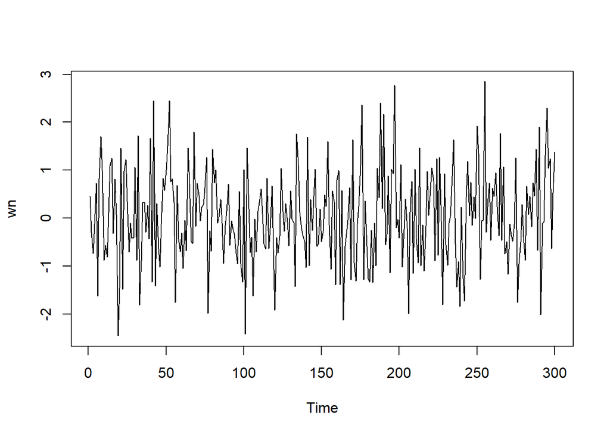

```r
ts.plot(wn)
```

Dapat terlihat bahwa *white noise* tidak memiliki autokorelasi dari ACF. Perhatikan bahwa lag ke-0 adalah korelasi observasi ke-t dengan dirinya sendiri. Nilai korelasi tersebut pasti 1. Sebagai alternatif, lag pertama di plot ACF dapat ditetapkan sebagai 1 (alih-alih 0) dengan menambahkan argumen `xlim(1, lag akhir)`. Plot tersebut dapat disandingkan bersamaan dengan membuat matriks $1 \times 2$ dengan `par(mfrow = c(1,2))`.

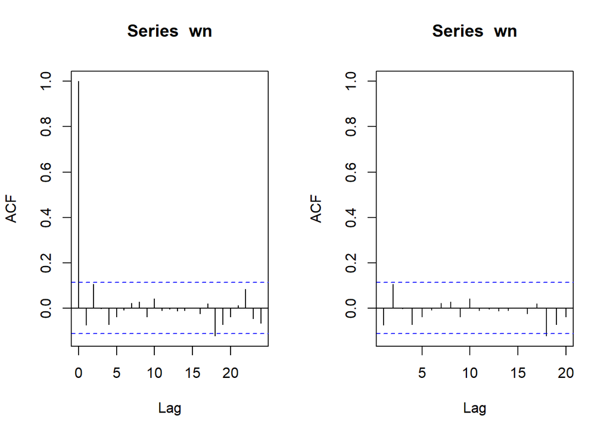

```r
par(mfrow = c(1, 2))
acf(wn)
acf(wn, xlim = c(1, 20))
```

## Proses MA

Proses MA dapat dituliskan sebagai berikut:

$$y_{t} = c + e_t + \theta_{1}e_{t-1} + \theta_{2}e_{t-2} + \dots +
\theta_{q}e_{t-q} = c+{e_t+\sum_{i=1}^p \theta_ie_{t-i}}$$
Terlihat bahwa $e_t$, atau *white noise*, berperan penting dalam pembangkitan proses MA.

## Pembangkitan Proses MA(2)

Akan dicoba membangkitkan proses MA(2) dengan $\theta_1 = 0.4$ dan $\theta_2 = 0.6$ sebanyak 300 observasi dan $c=0$. Karena diperlukan satu nilai awal untuk $e_{t-1}$, masukkan nilai pertama white noise sebagai nilai awal tersebut.

```r
set.seed(1065)
ma <- wn[1:2]
ma
```

```
## [1]  0.4543173 -0.3046325
```

Nilai-nilai selanjutnya dapat dicari melalui *loop*. Bentuk loop dapat dilihat dari rumus MA(2) yang hendak dibangkitkan:

$$y_t = e_t+0.4e_{t-1}+0.6e_{t-2}$$

```r
for(i in 3:300){
   ma[i] <- wn[i] + 0.4 * wn[i - 1] + 0.6 * wn[i - 2]
}
ma
```

```
##   [1]  0.45431730 -0.30463250 -0.58401985 -0.59900583  0.24195711 -1.40392204
##   [7]  0.61614546  1.05526755  2.17000837  0.54264188 -0.31657839 -1.55901039
##  [13] -0.54345033  0.65467534  1.75385349  0.83337669  1.43570064  0.20866919
##  [19] -1.93709837 -2.40297548 -0.60676381 -1.77854346  1.26322151  0.72518399
##  [25]  1.43304998  0.16623305 -0.17227808 -0.88013302 -0.64123255  0.64360861
##  [31] -0.69784448  2.00274922 -1.64568494 -0.57758326 -1.11374790 -0.06500922
##  [37]  0.03705205  0.34960220 -0.50569756  1.64693095 -0.93122399  2.91552674
##  [43] -1.23551162  1.20524921 -1.35924626 -1.09209465 -0.90931483  0.17400539
##  [49]  0.83800716  1.73515140  2.25412752  3.64898558  2.64293703  2.59459772
##  [55]  1.11655485 -1.13231191  0.17939077 -1.21816045 -0.46346278 -0.85503828
##  [61] -1.58972250 -0.65328945 -1.32884492  1.16471271  0.89966254  0.67866850
##  [67] -0.28605565  1.29289980  0.23399521  1.73448393  0.67527500  0.57808690
##  [73]  0.49872195  0.34519266  0.88485068  1.69030130 -1.09655100 -0.30051556
##  [79] -1.98804644  1.00521593  0.90221769  2.16235359  0.74482158  0.58199772
##  [85]  0.33863317  0.06320378 -0.75039867 -0.58836141 -0.48429074  0.67906693
```

[output cut: 35 more lines]

Selain menggunakan cara di atas, pembangkitan proses MA(2) dapat dilakukan dengan fungsi `arima.sim()` sebagai berikut.

```r
set.seed(1065)
ma2 <- arima.sim(list(order=c(0,0,2), ma=c(0.4, 0.6)), n=300)
ma2
```

```
## Time Series:
## Start = 1
## End = 300
## Frequency = 1
##   [1] -0.58401985 -0.59900583  0.24195711 -1.40392204  0.61614546  1.05526755
##   [7]  2.17000837  0.54264188 -0.31657839 -1.55901039 -0.54345033  0.65467534
##  [13]  1.75385349  0.83337669  1.43570064  0.20866919 -1.93709837 -2.40297548
##  [19] -0.60676381 -1.77854346  1.26322151  0.72518399  1.43304998  0.16623305
##  [25] -0.17227808 -0.88013302 -0.64123255  0.64360861 -0.69784448  2.00274922
##  [31] -1.64568494 -0.57758326 -1.11374790 -0.06500922  0.03705205  0.34960220
##  [37] -0.50569756  1.64693095 -0.93122399  2.91552674 -1.23551162  1.20524921
##  [43] -1.35924626 -1.09209465 -0.90931483  0.17400539  0.83800716  1.73515140
##  [49]  2.25412752  3.64898558  2.64293703  2.59459772  1.11655485 -1.13231191
##  [55]  0.17939077 -1.21816045 -0.46346278 -0.85503828 -1.58972250 -0.65328945
##  [61] -1.32884492  1.16471271  0.89966254  0.67866850 -0.28605565  1.29289980
```

[output cut: 39 more lines]

## Karakteristik MA(2)

### Plot Time Series

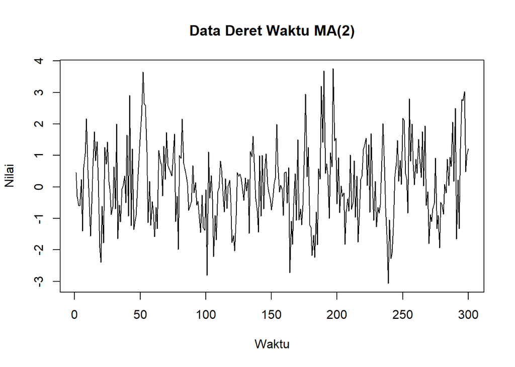

```r
plot(ma, type = 'l', main = 'Data Deret Waktu MA(2)', xlab = 'Waktu', ylab = 'Nilai')
```

Berdasarkan plot time series, terlihat bahwa data MA(2) yang dibangkitkan stasioner dalam rataan

### Plot ACF

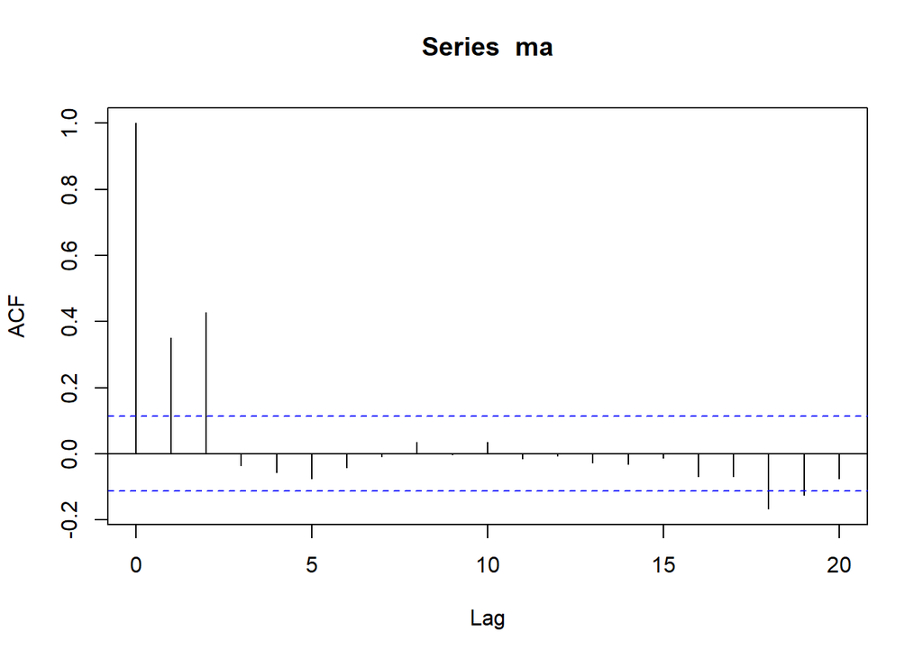

```r
acf(ma,lag.max = 20)
```

### Plot PACF

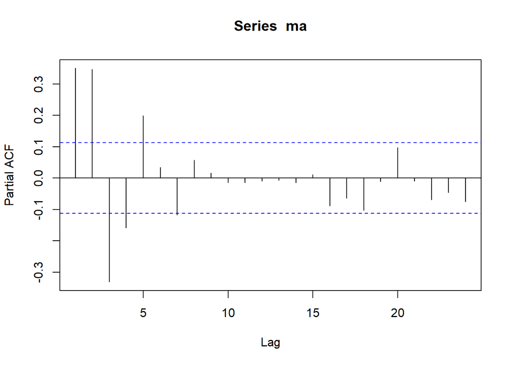

```r
pacf(ma)
```

### Plot EACF

```r
TSA::eacf(ma)
```

```
## AR/MA
##   0 1 2 3 4 5 6 7 8 9 10 11 12 13
## 0 x x o o o o o o o o o  o  o  o
## 1 x x x o o o o o o o o  o  o  o
## 2 x x x o o o o o o o o  o  o  o
## 3 x x x x x o o o o o o  o  o  o
## 4 x x o o o o o o o o o  o  o  o
## 5 x x o o o o o o o o o  o  o  o
## 6 x x o x o o o o o o o  o  o  o
## 7 x x o x o o o o o o o  o  o  o
```

Berdasarkan pola segitiga nol pada plot EACF, terlihat bahwa segitiga nol berada pada ordo AR(0) dan ordo MA(2)

### Scatterplot Antar Lag

#### Korelasi antara $Y_t$ dengan $Y_{t-1}$

```r
#Yt
yt_ma2 <- ma[-1]
yt_ma2
```

```
##   [1] -0.30463250 -0.58401985 -0.59900583  0.24195711 -1.40392204  0.61614546
##   [7]  1.05526755  2.17000837  0.54264188 -0.31657839 -1.55901039 -0.54345033
##  [13]  0.65467534  1.75385349  0.83337669  1.43570064  0.20866919 -1.93709837
##  [19] -2.40297548 -0.60676381 -1.77854346  1.26322151  0.72518399  1.43304998
##  [25]  0.16623305 -0.17227808 -0.88013302 -0.64123255  0.64360861 -0.69784448
##  [31]  2.00274922 -1.64568494 -0.57758326 -1.11374790 -0.06500922  0.03705205
##  [37]  0.34960220 -0.50569756  1.64693095 -0.93122399  2.91552674 -1.23551162
##  [43]  1.20524921 -1.35924626 -1.09209465 -0.90931483  0.17400539  0.83800716
##  [49]  1.73515140  2.25412752  3.64898558  2.64293703  2.59459772  1.11655485
##  [55] -1.13231191  0.17939077 -1.21816045 -0.46346278 -0.85503828 -1.58972250
##  [61] -0.65328945 -1.32884492  1.16471271  0.89966254  0.67866850 -0.28605565
##  [67]  1.29289980  0.23399521  1.73448393  0.67527500  0.57808690  0.49872195
##  [73]  0.34519266  0.88485068  1.69030130 -1.09655100 -0.30051556 -1.98804644
##  [79]  1.00521593  0.90221769  2.16235359  0.74482158  0.58199772  0.33863317
##  [85]  0.06320378 -0.75039867 -0.58836141 -0.48429074  0.67906693 -0.19267062
```

[output cut: 35 more lines]

```r
#Yt-1
yt_1_ma2 <- ma[-300]
yt_1_ma2
```

```
##   [1]  0.45431730 -0.30463250 -0.58401985 -0.59900583  0.24195711 -1.40392204
##   [7]  0.61614546  1.05526755  2.17000837  0.54264188 -0.31657839 -1.55901039
##  [13] -0.54345033  0.65467534  1.75385349  0.83337669  1.43570064  0.20866919
##  [19] -1.93709837 -2.40297548 -0.60676381 -1.77854346  1.26322151  0.72518399
##  [25]  1.43304998  0.16623305 -0.17227808 -0.88013302 -0.64123255  0.64360861
##  [31] -0.69784448  2.00274922 -1.64568494 -0.57758326 -1.11374790 -0.06500922
##  [37]  0.03705205  0.34960220 -0.50569756  1.64693095 -0.93122399  2.91552674
##  [43] -1.23551162  1.20524921 -1.35924626 -1.09209465 -0.90931483  0.17400539
##  [49]  0.83800716  1.73515140  2.25412752  3.64898558  2.64293703  2.59459772
##  [55]  1.11655485 -1.13231191  0.17939077 -1.21816045 -0.46346278 -0.85503828
##  [61] -1.58972250 -0.65328945 -1.32884492  1.16471271  0.89966254  0.67866850
##  [67] -0.28605565  1.29289980  0.23399521  1.73448393  0.67527500  0.57808690
##  [73]  0.49872195  0.34519266  0.88485068  1.69030130 -1.09655100 -0.30051556
##  [79] -1.98804644  1.00521593  0.90221769  2.16235359  0.74482158  0.58199772
##  [85]  0.33863317  0.06320378 -0.75039867 -0.58836141 -0.48429074  0.67906693
```

[output cut: 35 more lines]

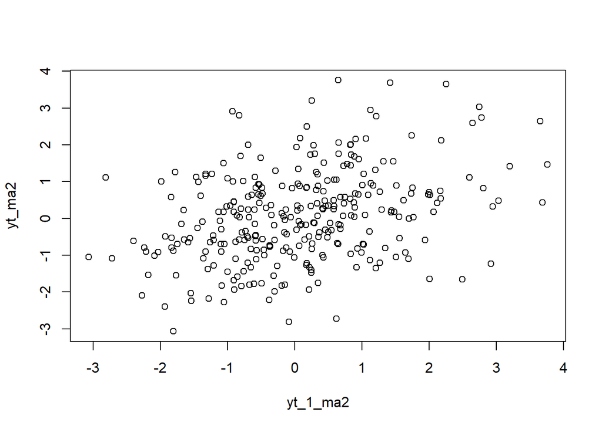

```r
plot(y=yt_ma2,x=yt_1_ma2)
```

Berdasarkan scatterplot tersebut, terlihat bahwa terdapat hubungan positif antara $Y_t$ dengan $Y_{t-1}$. Hal ini sesuai dengan teori yang ada

```r
cor(yt_ma2,yt_1_ma2)
```

```
## [1] 0.3507699
```

#### Korelasi antara $Y_t$ dengan $Y_{t-2}$

```r
#Yt
yt_ma2 <- ma[-c(1,2)]
yt_ma2
```

```
##   [1] -0.58401985 -0.59900583  0.24195711 -1.40392204  0.61614546  1.05526755
##   [7]  2.17000837  0.54264188 -0.31657839 -1.55901039 -0.54345033  0.65467534
##  [13]  1.75385349  0.83337669  1.43570064  0.20866919 -1.93709837 -2.40297548
##  [19] -0.60676381 -1.77854346  1.26322151  0.72518399  1.43304998  0.16623305
##  [25] -0.17227808 -0.88013302 -0.64123255  0.64360861 -0.69784448  2.00274922
##  [31] -1.64568494 -0.57758326 -1.11374790 -0.06500922  0.03705205  0.34960220
##  [37] -0.50569756  1.64693095 -0.93122399  2.91552674 -1.23551162  1.20524921
##  [43] -1.35924626 -1.09209465 -0.90931483  0.17400539  0.83800716  1.73515140
##  [49]  2.25412752  3.64898558  2.64293703  2.59459772  1.11655485 -1.13231191
##  [55]  0.17939077 -1.21816045 -0.46346278 -0.85503828 -1.58972250 -0.65328945
##  [61] -1.32884492  1.16471271  0.89966254  0.67866850 -0.28605565  1.29289980
##  [67]  0.23399521  1.73448393  0.67527500  0.57808690  0.49872195  0.34519266
##  [73]  0.88485068  1.69030130 -1.09655100 -0.30051556 -1.98804644  1.00521593
##  [79]  0.90221769  2.16235359  0.74482158  0.58199772  0.33863317  0.06320378
##  [85] -0.75039867 -0.58836141 -0.48429074  0.67906693 -0.19267062  0.14667012
```

[output cut: 35 more lines]

```r
#Yt-2
yt_2_ma2 <- ma[-c(299,300)]
yt_2_ma2
```

```
##   [1]  0.45431730 -0.30463250 -0.58401985 -0.59900583  0.24195711 -1.40392204
##   [7]  0.61614546  1.05526755  2.17000837  0.54264188 -0.31657839 -1.55901039
##  [13] -0.54345033  0.65467534  1.75385349  0.83337669  1.43570064  0.20866919
##  [19] -1.93709837 -2.40297548 -0.60676381 -1.77854346  1.26322151  0.72518399
##  [25]  1.43304998  0.16623305 -0.17227808 -0.88013302 -0.64123255  0.64360861
##  [31] -0.69784448  2.00274922 -1.64568494 -0.57758326 -1.11374790 -0.06500922
##  [37]  0.03705205  0.34960220 -0.50569756  1.64693095 -0.93122399  2.91552674
##  [43] -1.23551162  1.20524921 -1.35924626 -1.09209465 -0.90931483  0.17400539
##  [49]  0.83800716  1.73515140  2.25412752  3.64898558  2.64293703  2.59459772
##  [55]  1.11655485 -1.13231191  0.17939077 -1.21816045 -0.46346278 -0.85503828
##  [61] -1.58972250 -0.65328945 -1.32884492  1.16471271  0.89966254  0.67866850
##  [67] -0.28605565  1.29289980  0.23399521  1.73448393  0.67527500  0.57808690
##  [73]  0.49872195  0.34519266  0.88485068  1.69030130 -1.09655100 -0.30051556
##  [79] -1.98804644  1.00521593  0.90221769  2.16235359  0.74482158  0.58199772
##  [85]  0.33863317  0.06320378 -0.75039867 -0.58836141 -0.48429074  0.67906693
```

[output cut: 35 more lines]

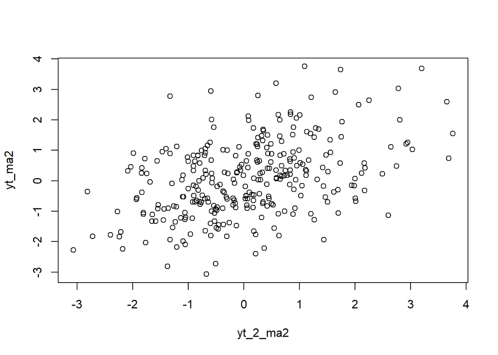

```r
plot(y=yt_ma2,x=yt_2_ma2)
```

```r
cor(yt_ma2,yt_2_ma2)
```

```
## [1] 0.4284992
```

#### Korelasi antara $Y_t$ dengan $Y_{t-3}$

```r
#Yt
yt_ma2 <- ma[-c(1,2,3)]
yt_ma2
```

```
##   [1] -0.59900583  0.24195711 -1.40392204  0.61614546  1.05526755  2.17000837
##   [7]  0.54264188 -0.31657839 -1.55901039 -0.54345033  0.65467534  1.75385349
##  [13]  0.83337669  1.43570064  0.20866919 -1.93709837 -2.40297548 -0.60676381
##  [19] -1.77854346  1.26322151  0.72518399  1.43304998  0.16623305 -0.17227808
##  [25] -0.88013302 -0.64123255  0.64360861 -0.69784448  2.00274922 -1.64568494
##  [31] -0.57758326 -1.11374790 -0.06500922  0.03705205  0.34960220 -0.50569756
##  [37]  1.64693095 -0.93122399  2.91552674 -1.23551162  1.20524921 -1.35924626
##  [43] -1.09209465 -0.90931483  0.17400539  0.83800716  1.73515140  2.25412752
##  [49]  3.64898558  2.64293703  2.59459772  1.11655485 -1.13231191  0.17939077
##  [55] -1.21816045 -0.46346278 -0.85503828 -1.58972250 -0.65328945 -1.32884492
##  [61]  1.16471271  0.89966254  0.67866850 -0.28605565  1.29289980  0.23399521
##  [67]  1.73448393  0.67527500  0.57808690  0.49872195  0.34519266  0.88485068
##  [73]  1.69030130 -1.09655100 -0.30051556 -1.98804644  1.00521593  0.90221769
##  [79]  2.16235359  0.74482158  0.58199772  0.33863317  0.06320378 -0.75039867
##  [85] -0.58836141 -0.48429074  0.67906693 -0.19267062  0.14667012 -0.58100750
```

[output cut: 35 more lines]

```r
#Yt-2
yt_3_ma2 <- ma[-c(298,299,300)]
yt_3_ma2
```

```
##   [1]  0.45431730 -0.30463250 -0.58401985 -0.59900583  0.24195711 -1.40392204
##   [7]  0.61614546  1.05526755  2.17000837  0.54264188 -0.31657839 -1.55901039
##  [13] -0.54345033  0.65467534  1.75385349  0.83337669  1.43570064  0.20866919
##  [19] -1.93709837 -2.40297548 -0.60676381 -1.77854346  1.26322151  0.72518399
##  [25]  1.43304998  0.16623305 -0.17227808 -0.88013302 -0.64123255  0.64360861
##  [31] -0.69784448  2.00274922 -1.64568494 -0.57758326 -1.11374790 -0.06500922
##  [37]  0.03705205  0.34960220 -0.50569756  1.64693095 -0.93122399  2.91552674
##  [43] -1.23551162  1.20524921 -1.35924626 -1.09209465 -0.90931483  0.17400539
##  [49]  0.83800716  1.73515140  2.25412752  3.64898558  2.64293703  2.59459772
##  [55]  1.11655485 -1.13231191  0.17939077 -1.21816045 -0.46346278 -0.85503828
##  [61] -1.58972250 -0.65328945 -1.32884492  1.16471271  0.89966254  0.67866850
##  [67] -0.28605565  1.29289980  0.23399521  1.73448393  0.67527500  0.57808690
##  [73]  0.49872195  0.34519266  0.88485068  1.69030130 -1.09655100 -0.30051556
##  [79] -1.98804644  1.00521593  0.90221769  2.16235359  0.74482158  0.58199772
##  [85]  0.33863317  0.06320378 -0.75039867 -0.58836141 -0.48429074  0.67906693
```

[output cut: 35 more lines]

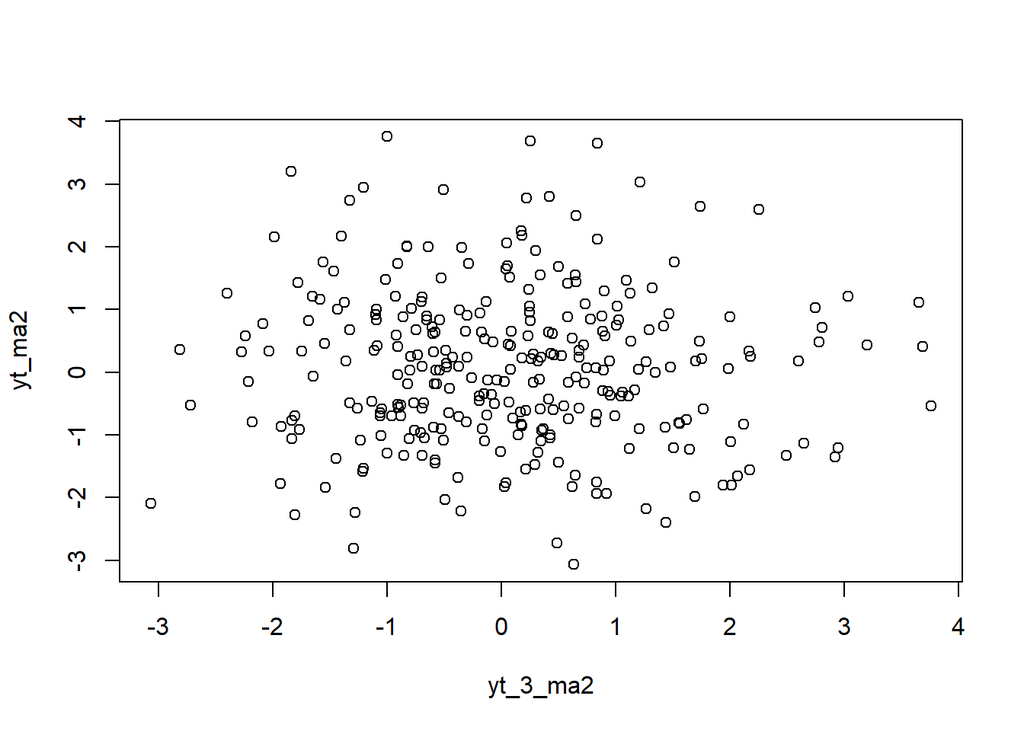

```r
plot(y=yt_ma2,x=yt_3_ma2)
```

```r
cor(yt_ma2,yt_3_ma2)
```

```
## [1] -0.0362887
```

## Proses AR

Proses AR dapat dituliskan sebagai berikut:

$$y_{t} = c + e_t + \phi_{1}Y_{t-1} +
\phi_{2}Y_{t-2} + \dots + \phi_{q}Y_{t-q} = c+{e_t+\sum_{i=1}^p
\phi_iY_{t-i}}$$
Terlihat bahwa $Y_t$ berperan penting dalam pembangkitan proses AR.

## Pembangkitan Proses AR

Akan dicoba membangkitkan proses AR(2) dengan $\phi_1 = 0.5$ dan $\phi_1 = 0.2$ sebanyak 300 observasi dan $c=0$.

```r
set.seed(1065)
```

Nilai-nilai selanjutnya dapat dicari melalui *loop*. Bentuk loop dapat dilihat dari rumus AR(2) yang hendak dibangkitkan:

$$Y_t = e_t+0.5Y_{t-1}+0.2Y_{t-2}$$

```r
set.seed(1065)
n<-length(wn)
n
```

```
## [1] 300
```

```r
ar <- c(1:n)
ar
```

```
##   [1]   1   2   3   4   5   6   7   8   9  10  11  12  13  14  15  16  17  18
##  [19]  19  20  21  22  23  24  25  26  27  28  29  30  31  32  33  34  35  36
##  [37]  37  38  39  40  41  42  43  44  45  46  47  48  49  50  51  52  53  54
##  [55]  55  56  57  58  59  60  61  62  63  64  65  66  67  68  69  70  71  72
##  [73]  73  74  75  76  77  78  79  80  81  82  83  84  85  86  87  88  89  90
##  [91]  91  92  93  94  95  96  97  98  99 100 101 102 103 104 105 106 107 108
## [109] 109 110 111 112 113 114 115 116 117 118 119 120 121 122 123 124 125 126
## [127] 127 128 129 130 131 132 133 134 135 136 137 138 139 140 141 142 143 144
## [145] 145 146 147 148 149 150 151 152 153 154 155 156 157 158 159 160 161 162
## [163] 163 164 165 166 167 168 169 170 171 172 173 174 175 176 177 178 179 180
## [181] 181 182 183 184 185 186 187 188 189 190 191 192 193 194 195 196 197 198
## [199] 199 200 201 202 203 204 205 206 207 208 209 210 211 212 213 214 215 216
## [217] 217 218 219 220 221 222 223 224 225 226 227 228 229 230 231 232 233 234
## [235] 235 236 237 238 239 240 241 242 243 244 245 246 247 248 249 250 251 252
## [253] 253 254 255 256 257 258 259 260 261 262 263 264 265 266 267 268 269 270
## [271] 271 272 273 274 275 276 277 278 279 280 281 282 283 284 285 286 287 288
## [289] 289 290 291 292 293 294 295 296 297 298 299 300
```

```r
for (i in 3:n) {
  ar[i] <- wn[i] + 0.5 * ar[i-1] + 0.2 * ar[i-2]
  }
ar
```

```
##   [1]  1.000000000  2.000000000  0.465242772  0.510297945  1.079938347
##   [6] -0.981195536  0.551780586  1.778297043  1.994220252  0.478337655
##  [11]  0.074377875 -0.676040790 -0.204855243  0.855062084  1.632360591
##  [16]  0.666630449  1.476232527  0.945870832 -1.688554951 -2.120041127
##  [21]  0.055521885 -1.877129431  0.056161970  0.872919454  0.802462973
##  [26] -0.132018523 -0.007523697 -0.444795417 -0.638078829  0.650058582
##  [31] -0.675147953  1.509377305 -1.189264817 -1.176934390 -0.501042756
##  [36] -0.150521972 -0.467738439  0.001304378 -0.529342913  1.397932544
##  [41] -0.741195099  2.360826941 -0.383496688  0.580831920 -0.416292909
##  [46] -1.112319829 -0.762591708  0.231718708  0.541060687  1.319650494
##  [51]  2.274422541  3.845907044  3.139037695  3.161958703  2.539318560
##  [56]  0.143571378  1.264113025  0.223912678 -0.334618763 -0.435691178
##  [61] -1.329587482 -0.799395568 -1.348583881  0.632207250  0.769279230
##  [66]  0.020765628 -0.359426240  1.620995029  0.568184405  1.333013268
##  [71]  1.267786411  0.848692361  0.904761077  0.907650722  1.269301002
```

[output cut: 45 more lines]

Selain menggunakan cara di atas, pembangkitan proses AR dapat dilakukan dengan fungsi `arima.sim()` sebagai berikut.

```r
set.seed(1065)
ar2 <- arima.sim(list(order=c(2,0,0), ar=c(0.5, 0.2)), n=300)
ar2
```

```
## Time Series:
## Start = 1
## End = 300
## Frequency = 1
##   [1] -0.134471577 -0.009393776 -0.446221067 -0.639165671  0.649230032
##   [6] -0.675779596  1.508895773 -1.189631912 -1.177214244 -0.501256102
##  [11] -0.150684616 -0.467862430  0.001209853 -0.529414973  1.397877609
##  [16] -0.741236978  2.360795014 -0.383521027  0.580813365 -0.416307055
##  [21] -1.112330613 -0.762599929  0.231712440  0.541055910  1.319646852
##  [26]  2.274419764  3.845904927  3.139036081  3.161957473  2.539317622
##  [31]  0.143570663  1.264112480  0.223912262 -0.334619080 -0.435691419
##  [36] -1.329587666 -0.799395709 -1.348583988  0.632207169  0.769279168
##  [41]  0.020765581 -0.359426276  1.620995001  0.568184384  1.333013252
##  [46]  1.267786399  0.848692352  0.904761070  0.907650717  1.269300998
##  [51]  2.081353545 -0.688797248 -0.194413526 -0.926497874  0.939468318
```

[output cut: 49 more lines]

## Karakteristik AR(2)

### Plot Time Series

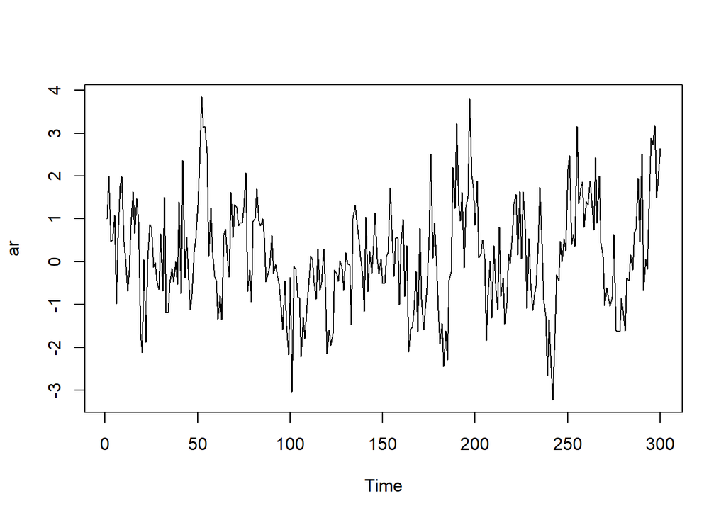

```r
ts.plot(ar)
```

Berdasarkan plot time series tersebut terlihat bahwa data cenderung stasioner pada rataan

### Plot ACF

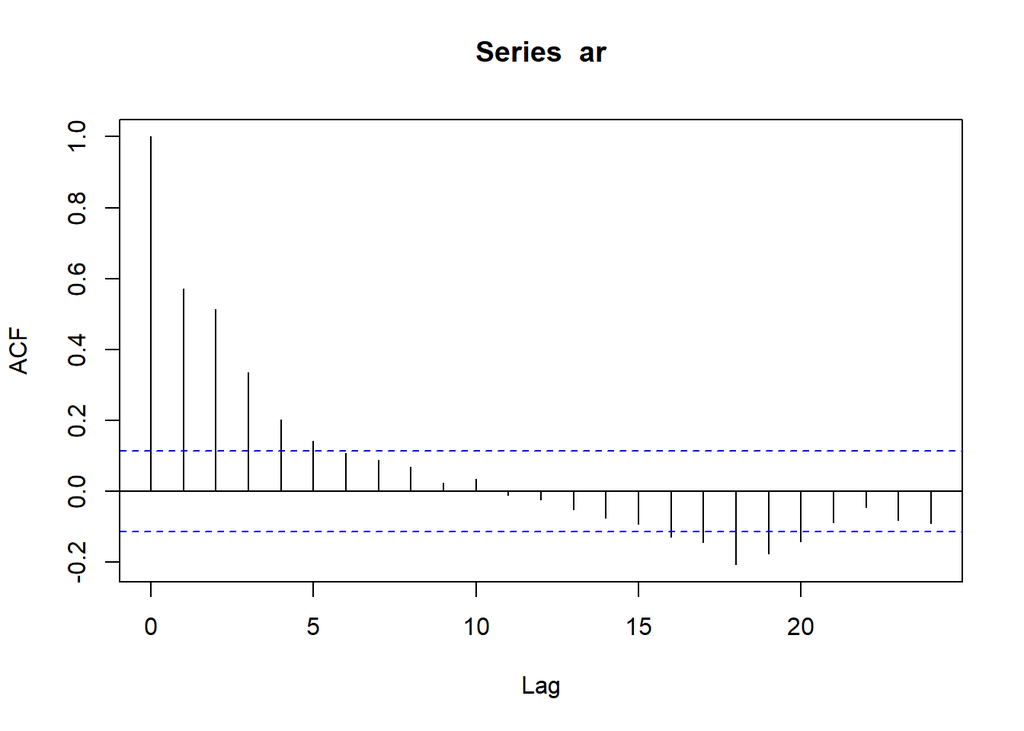

```r
acf(ar)
```

Berdasarkan plot ACF tersebut terlihat bahwa plot ACF cenderung *tails off* dan cenderung membentuk pola grafik sinus

### Plot PACF

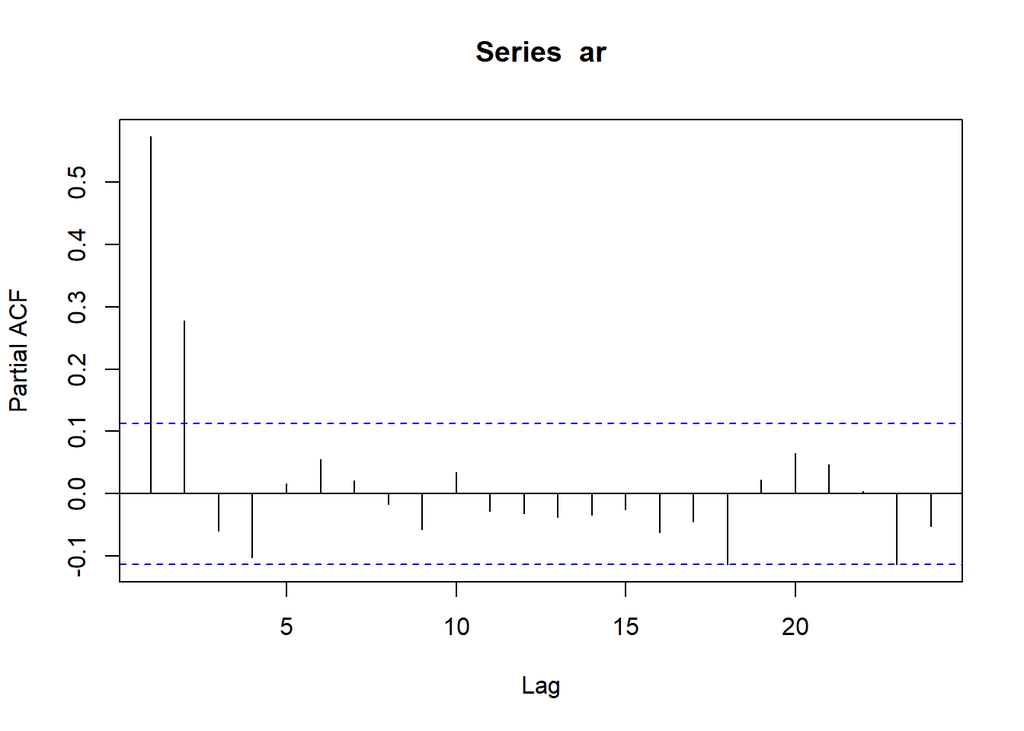

```r
pacf(ar)
```

### Plot EACF

```r
TSA::eacf(ar)
```

```
## AR/MA
##   0 1 2 3 4 5 6 7 8 9 10 11 12 13
## 0 x x x x x o o o o o o  o  o  o
## 1 x x o o o o o o o o o  o  o  o
## 2 x x o o o o o o o o o  o  o  o
## 3 x x x o o o o o o o o  o  o  o
## 4 x x x o o o o o o o o  o  o  o
## 5 x x o o o o o o o o o  o  o  o
## 6 x x o x o o o o o o o  o  o  o
## 7 x x x o x o o o o o o  o  o  o
```

Berdasarkan pola segitiga nol pada plot EACF, terlihat bahwa segitiga nol berada pada ordo AR(2) dan ordo MA(2)

### Scatterplot Antar Lag

#### Korelasi antara $Y_t$ dengan $Y_{t-1}$

```r
#Yt
yt_ar2 <- ar[-1]
yt_ar2
```

```
##   [1]  2.000000000  0.465242772  0.510297945  1.079938347 -0.981195536
##   [6]  0.551780586  1.778297043  1.994220252  0.478337655  0.074377875
##  [11] -0.676040790 -0.204855243  0.855062084  1.632360591  0.666630449
##  [16]  1.476232527  0.945870832 -1.688554951 -2.120041127  0.055521885
##  [21] -1.877129431  0.056161970  0.872919454  0.802462973 -0.132018523
##  [26] -0.007523697 -0.444795417 -0.638078829  0.650058582 -0.675147953
##  [31]  1.509377305 -1.189264817 -1.176934390 -0.501042756 -0.150521972
##  [36] -0.467738439  0.001304378 -0.529342913  1.397932544 -0.741195099
##  [41]  2.360826941 -0.383496688  0.580831920 -0.416292909 -1.112319829
##  [46] -0.762591708  0.231718708  0.541060687  1.319650494  2.274422541
##  [51]  3.845907044  3.139037695  3.161958703  2.539318560  0.143571378
##  [56]  1.264113025  0.223912678 -0.334618763 -0.435691178 -1.329587482
##  [61] -0.799395568 -1.348583881  0.632207250  0.769279230  0.020765628
##  [66] -0.359426240  1.620995029  0.568184405  1.333013268  1.267786411
##  [71]  0.848692361  0.904761077  0.907650722  1.269301002  2.081353549
```

[output cut: 45 more lines]

```r
#Yt-1
yt_1_ar2 <- ar[-300]
yt_1_ar2
```

```
##   [1]  1.000000000  2.000000000  0.465242772  0.510297945  1.079938347
##   [6] -0.981195536  0.551780586  1.778297043  1.994220252  0.478337655
##  [11]  0.074377875 -0.676040790 -0.204855243  0.855062084  1.632360591
##  [16]  0.666630449  1.476232527  0.945870832 -1.688554951 -2.120041127
##  [21]  0.055521885 -1.877129431  0.056161970  0.872919454  0.802462973
##  [26] -0.132018523 -0.007523697 -0.444795417 -0.638078829  0.650058582
##  [31] -0.675147953  1.509377305 -1.189264817 -1.176934390 -0.501042756
##  [36] -0.150521972 -0.467738439  0.001304378 -0.529342913  1.397932544
##  [41] -0.741195099  2.360826941 -0.383496688  0.580831920 -0.416292909
##  [46] -1.112319829 -0.762591708  0.231718708  0.541060687  1.319650494
##  [51]  2.274422541  3.845907044  3.139037695  3.161958703  2.539318560
##  [56]  0.143571378  1.264113025  0.223912678 -0.334618763 -0.435691178
##  [61] -1.329587482 -0.799395568 -1.348583881  0.632207250  0.769279230
##  [66]  0.020765628 -0.359426240  1.620995029  0.568184405  1.333013268
##  [71]  1.267786411  0.848692361  0.904761077  0.907650722  1.269301002
```

[output cut: 45 more lines]

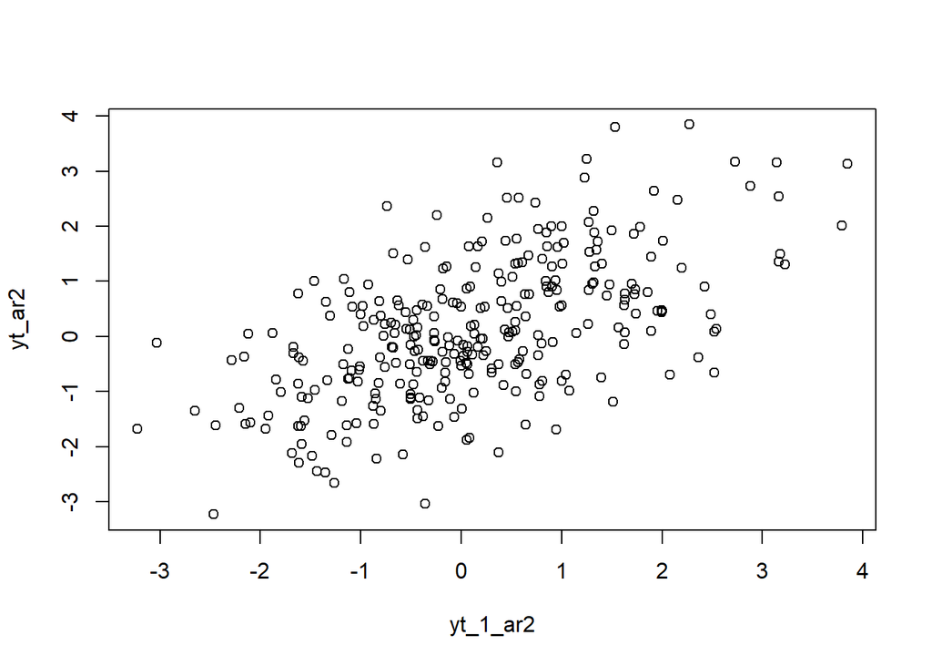

```r
plot(y=yt_ar2,x=yt_1_ar2)
```

Berdasarkan scatterplot tersebut, terlihat bahwa terdapat hubungan positif antara $Y_t$ dengan $Y_{t-1}$. Hal ini sesuai dengan teori yang ada

```r
cor(yt_ar2,yt_1_ar2)
```

```
## [1] 0.5765674
```

#### Korelasi antara $Y_t$ dengan $Y_{t-2}$

```r
#Yt
yt_ar2 <- ar[-c(1,2)]
yt_ar2
```

```
##   [1]  0.465242772  0.510297945  1.079938347 -0.981195536  0.551780586
##   [6]  1.778297043  1.994220252  0.478337655  0.074377875 -0.676040790
##  [11] -0.204855243  0.855062084  1.632360591  0.666630449  1.476232527
##  [16]  0.945870832 -1.688554951 -2.120041127  0.055521885 -1.877129431
##  [21]  0.056161970  0.872919454  0.802462973 -0.132018523 -0.007523697
##  [26] -0.444795417 -0.638078829  0.650058582 -0.675147953  1.509377305
##  [31] -1.189264817 -1.176934390 -0.501042756 -0.150521972 -0.467738439
##  [36]  0.001304378 -0.529342913  1.397932544 -0.741195099  2.360826941
##  [41] -0.383496688  0.580831920 -0.416292909 -1.112319829 -0.762591708
##  [46]  0.231718708  0.541060687  1.319650494  2.274422541  3.845907044
##  [51]  3.139037695  3.161958703  2.539318560  0.143571378  1.264113025
##  [56]  0.223912678 -0.334618763 -0.435691178 -1.329587482 -0.799395568
##  [61] -1.348583881  0.632207250  0.769279230  0.020765628 -0.359426240
##  [66]  1.620995029  0.568184405  1.333013268  1.267786411  0.848692361
##  [71]  0.904761077  0.907650722  1.269301002  2.081353549 -0.688797246
```

[output cut: 45 more lines]

```r
#Yt-2
yt_2_ar2 <- ar[-c(299,300)]
yt_2_ar2
```

```
##   [1]  1.000000000  2.000000000  0.465242772  0.510297945  1.079938347
##   [6] -0.981195536  0.551780586  1.778297043  1.994220252  0.478337655
##  [11]  0.074377875 -0.676040790 -0.204855243  0.855062084  1.632360591
##  [16]  0.666630449  1.476232527  0.945870832 -1.688554951 -2.120041127
##  [21]  0.055521885 -1.877129431  0.056161970  0.872919454  0.802462973
##  [26] -0.132018523 -0.007523697 -0.444795417 -0.638078829  0.650058582
##  [31] -0.675147953  1.509377305 -1.189264817 -1.176934390 -0.501042756
##  [36] -0.150521972 -0.467738439  0.001304378 -0.529342913  1.397932544
##  [41] -0.741195099  2.360826941 -0.383496688  0.580831920 -0.416292909
##  [46] -1.112319829 -0.762591708  0.231718708  0.541060687  1.319650494
##  [51]  2.274422541  3.845907044  3.139037695  3.161958703  2.539318560
##  [56]  0.143571378  1.264113025  0.223912678 -0.334618763 -0.435691178
##  [61] -1.329587482 -0.799395568 -1.348583881  0.632207250  0.769279230
##  [66]  0.020765628 -0.359426240  1.620995029  0.568184405  1.333013268
##  [71]  1.267786411  0.848692361  0.904761077  0.907650722  1.269301002
```

[output cut: 45 more lines]

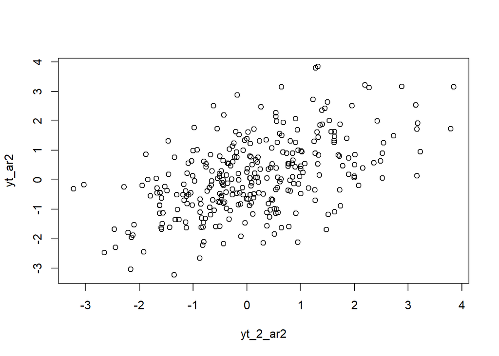

```r
plot(y=yt_ar2,x=yt_2_ar2)
```

Berdasarkan scatterplot tersebut, terlihat bahwa terdapat hubungan positif antara $Y_t$ dengan $Y_{t-2}$. Hal ini sesuai dengan teori yang ada

```r
cor(yt_ar2,yt_2_ar2)
```

```
## [1] 0.521765
```

#### Korelasi antara $Y_t$ dengan $Y_{t-3}$

```r
#Yt
yt_ar2 <- ar[-c(1,2,3)]
yt_ar2
```

```
##   [1]  0.510297945  1.079938347 -0.981195536  0.551780586  1.778297043
##   [6]  1.994220252  0.478337655  0.074377875 -0.676040790 -0.204855243
##  [11]  0.855062084  1.632360591  0.666630449  1.476232527  0.945870832
##  [16] -1.688554951 -2.120041127  0.055521885 -1.877129431  0.056161970
##  [21]  0.872919454  0.802462973 -0.132018523 -0.007523697 -0.444795417
##  [26] -0.638078829  0.650058582 -0.675147953  1.509377305 -1.189264817
##  [31] -1.176934390 -0.501042756 -0.150521972 -0.467738439  0.001304378
##  [36] -0.529342913  1.397932544 -0.741195099  2.360826941 -0.383496688
##  [41]  0.580831920 -0.416292909 -1.112319829 -0.762591708  0.231718708
##  [46]  0.541060687  1.319650494  2.274422541  3.845907044  3.139037695
##  [51]  3.161958703  2.539318560  0.143571378  1.264113025  0.223912678
##  [56] -0.334618763 -0.435691178 -1.329587482 -0.799395568 -1.348583881
##  [61]  0.632207250  0.769279230  0.020765628 -0.359426240  1.620995029
##  [66]  0.568184405  1.333013268  1.267786411  0.848692361  0.904761077
##  [71]  0.907650722  1.269301002  2.081353549 -0.688797246 -0.194413524
```

[output cut: 45 more lines]

```r
#Yt-2
yt_3_ar2 <- ar[-c(298,299,300)]
yt_3_ar2
```

```
##   [1]  1.000000000  2.000000000  0.465242772  0.510297945  1.079938347
##   [6] -0.981195536  0.551780586  1.778297043  1.994220252  0.478337655
##  [11]  0.074377875 -0.676040790 -0.204855243  0.855062084  1.632360591
##  [16]  0.666630449  1.476232527  0.945870832 -1.688554951 -2.120041127
##  [21]  0.055521885 -1.877129431  0.056161970  0.872919454  0.802462973
##  [26] -0.132018523 -0.007523697 -0.444795417 -0.638078829  0.650058582
##  [31] -0.675147953  1.509377305 -1.189264817 -1.176934390 -0.501042756
##  [36] -0.150521972 -0.467738439  0.001304378 -0.529342913  1.397932544
##  [41] -0.741195099  2.360826941 -0.383496688  0.580831920 -0.416292909
##  [46] -1.112319829 -0.762591708  0.231718708  0.541060687  1.319650494
##  [51]  2.274422541  3.845907044  3.139037695  3.161958703  2.539318560
##  [56]  0.143571378  1.264113025  0.223912678 -0.334618763 -0.435691178
##  [61] -1.329587482 -0.799395568 -1.348583881  0.632207250  0.769279230
##  [66]  0.020765628 -0.359426240  1.620995029  0.568184405  1.333013268
##  [71]  1.267786411  0.848692361  0.904761077  0.907650722  1.269301002
```

[output cut: 45 more lines]

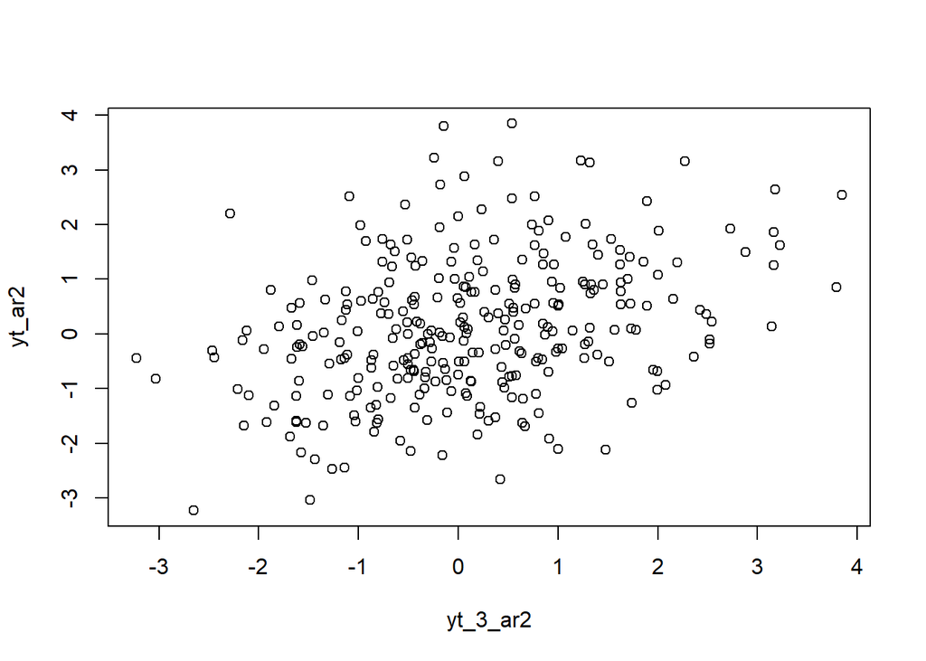

```r
plot(y=yt_ar2,x=yt_3_ar2)
```

```r
cor(yt_ar2,yt_3_ar2)
```

```
## [1] 0.3401476
```

## Fungsi pembangkitan ARMA

```r
set.seed(1065)
phi1 = 0.4
theta1 = 0.6
phi2 = 0.5
theta2 = 0.2
n = length(wn)

y.arma=c(1:n)
for (i in 3:n){
  y.arma[i] <- phi1*y.arma[i-1] + phi2*y.arma[i-2] + theta1*wn[i-1] + theta2*wn[i-2]+wn[i]
}
y.arma
```

```
##   [1]  1.00000000  2.00000000  0.47332673  0.56522642  0.97414924 -0.53637159
##   [7]  0.27133025  1.71018172  2.99891908  2.11678515  1.45682259  0.31915697
##  [13]  0.37629831  1.31198997  2.63802237  2.35666160  3.13494377  2.93249145
##  [19]  0.49167772 -1.26117744 -0.17568874 -1.60278186 -0.34321341  0.57558501
##  [25]  1.34228123  0.57378648  0.44490201 -0.15254682 -0.52192343  0.44158250
##  [31] -0.40489122  1.46384885 -0.57017851 -1.12229083 -1.30101942 -0.72783595
##  [37] -0.96762574 -0.59397436 -1.05713702  0.73368829 -0.65926959  2.08686724
##  [43]  0.29368519  1.10228749 -0.14513724 -0.84517366 -1.27201706 -0.37388700
##  [49]  0.26880882  1.43708395  2.93283293  5.44082719  6.17208344  6.95817835
##  [55]  6.84603973  4.82199612  5.04730049  4.05204239  3.31984735  2.53378556
##  [61]  1.30084162  1.05024208  0.15010726  1.63226837  2.19408662  1.93046449
##  [67]  1.19595342  2.82790661  2.53191153  3.40849426  3.51774403  3.49707139
##  [73]  3.45100466  3.54022314  3.99280556  5.07022710  2.92716783  2.50272912
##  [79]  1.21670569  2.71147068  3.16009146  4.35358486  3.97034156  3.92645793
##  [85]  3.93862139  3.67139645  2.51031147  2.10525472  1.96023222  2.60309147
```

[output cut: 35 more lines]

Pembangkitan ARMA(p,q) juga dapat dilakukan dengan fungsi `arima.sim` sebagai berikut.

```r
set.seed(1065)
arma22 <- arima.sim(list(order=c(2,0,2), ar =c(0.4,0.5), ma =c(0.6,0.2)), n=300)
arma22
```

```
## Time Series:
## Start = 1
## End = 300
## Frequency = 1
##   [1]  0.06081250 -0.95938218 -0.51316743 -1.48814639 -2.64080332 -1.77294378
##   [7] -4.10664353 -2.30835364 -2.07210051 -2.10576991 -2.60867516 -4.10466889
##  [13] -4.02117765 -4.70254009 -4.17109129 -3.75176475 -2.75891597 -2.46043339
##  [19] -2.71835561 -3.26005567 -2.31997178 -2.81365029 -2.70868924 -2.07201576
##  [25] -2.45903041 -4.18289989 -4.57960306 -5.27318496 -5.29462172 -4.08487753
##  [31] -3.58932453 -3.45662430 -3.01119092 -2.88365542 -3.22383439 -2.52384212
##  [37] -2.40812407 -2.21284924 -3.57211617 -1.65108173 -0.57078293  0.08162246
##  [43] -0.17271902 -0.48688018 -1.02547546 -2.04290860 -0.34999792 -1.33770310
##  [49] -0.57636127 -1.11984465 -0.35568185  0.53811772  0.15596001 -0.34924001
##  [55] -0.31144524 -0.78124922 -0.99065699 -0.55834126 -0.23633798  1.46719968
##  [61]  1.33944461  0.43675444  0.74553937  0.98344563 -0.30093911  0.40133532
```

[output cut: 39 more lines]

## Karakteristik ARMA(2,2)

### Plot Time Series

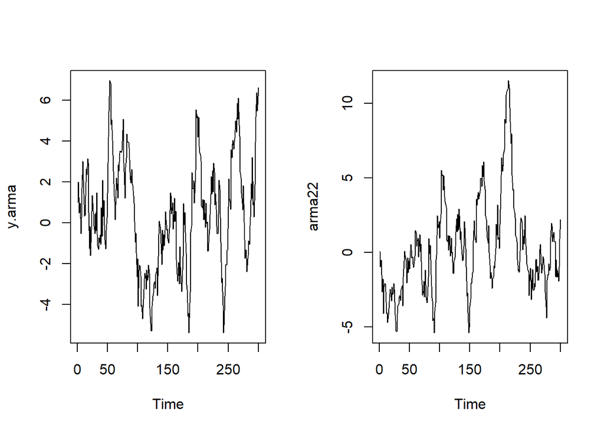

```r
par(mfrow = c(1, 2))
ts.plot(y.arma)
ts.plot(arma22)
```

### Plot ACF

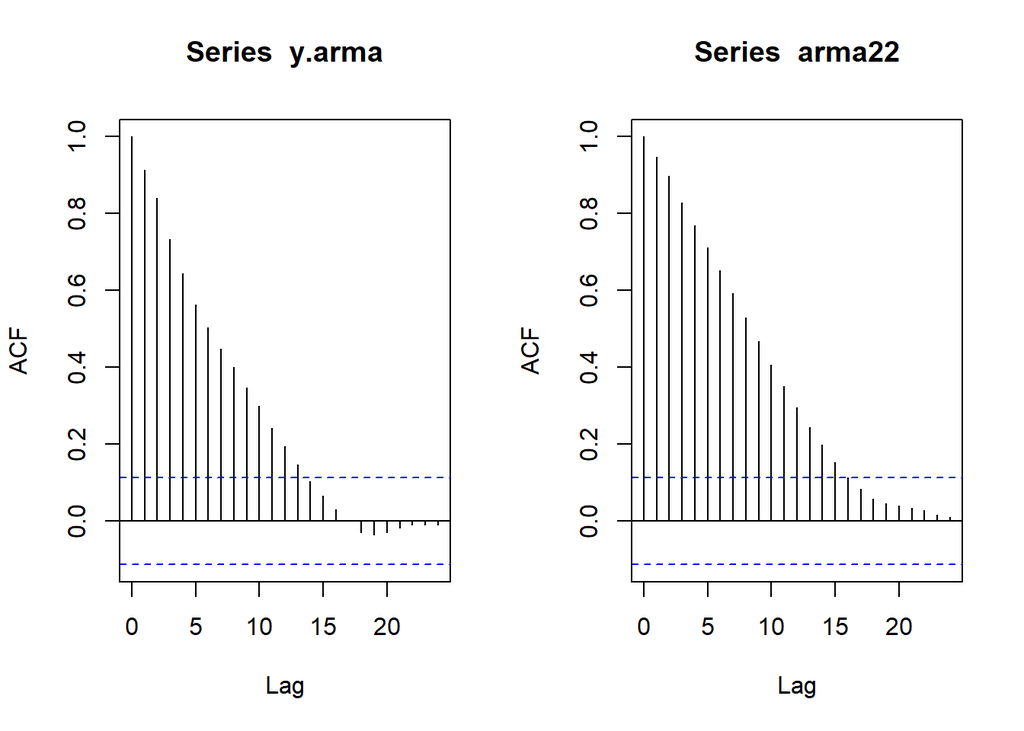

```r
par(mfrow = c(1, 2))
acf(y.arma)
acf(arma22)
```

Berdasarkan plot ACF tersebut, terlihat bahwa model ARMA(2,2) hasil simulasi memiliki plot ACF yang *tails off*, sesuai dengan teori yang ada

### Plot PACF

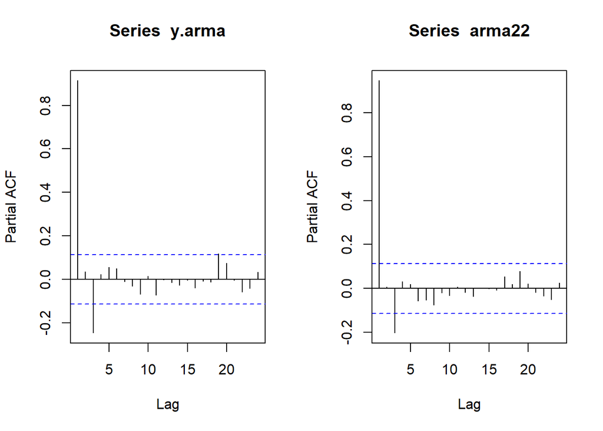

```r
par(mfrow = c(1, 2))
pacf(y.arma)
pacf(arma22)
```

### Plot EACF

```r
TSA::eacf(y.arma)
```

```
## AR/MA
##   0 1 2 3 4 5 6 7 8 9 10 11 12 13
## 0 x x x x x x x x x x x  x  x  o
## 1 o x o o o o o o o o o  o  o  o
## 2 x x o o o o o o o o o  o  o  o
## 3 x x o x o o o o o o o  o  o  o
## 4 x x x o o o o o o o o  o  o  o
## 5 x x o o o o o o o o o  o  o  o
## 6 x x o o o o x o o o o  o  o  o
## 7 x x x o o o o o o o o  o  o  o
```

```r
TSA::eacf(arma22)
```

```
## AR/MA
##   0 1 2 3 4 5 6 7 8 9 10 11 12 13
## 0 x x x x x x x x x x x  x  x  x
## 1 o x o o o o o o o o o  o  o  o
## 2 o x o o o o o o o o o  o  o  o
## 3 x x o o o o o o o o o  o  o  o
## 4 x o x o o o o o o o o  o  o  o
## 5 x x o o o x o o o o o  o  o  o
## 6 x o x o o o o o o o o  o  o  o
## 7 x o x x o o o o o o o  o  o  o
```

Berdasarkan pola segitiga nol pada plot EACF, terlihat bahwa segitiga nol berada pada ordo AR(1) dan ordo MA(2)

### Scatterplot Antar Lag

#### Korelasi antara $Y_t$ dengan $Y_{t-1}$

```r
#Yt
yt_arma <- arma22[-1]
yt_arma
```

```
##   [1] -0.95938218 -0.51316743 -1.48814639 -2.64080332 -1.77294378 -4.10664353
##   [7] -2.30835364 -2.07210051 -2.10576991 -2.60867516 -4.10466889 -4.02117765
##  [13] -4.70254009 -4.17109129 -3.75176475 -2.75891597 -2.46043339 -2.71835561
##  [19] -3.26005567 -2.31997178 -2.81365029 -2.70868924 -2.07201576 -2.45903041
##  [25] -4.18289989 -4.57960306 -5.27318496 -5.29462172 -4.08487753 -3.58932453
##  [31] -3.45662430 -3.01119092 -2.88365542 -3.22383439 -2.52384212 -2.40812407
##  [37] -2.21284924 -3.57211617 -1.65108173 -0.57078293  0.08162246 -0.17271902
##  [43] -0.48688018 -1.02547546 -2.04290860 -0.34999792 -1.33770310 -0.57636127
##  [49] -1.11984465 -0.35568185  0.53811772  0.15596001 -0.34924001 -0.31144524
##  [55] -0.78124922 -0.99065699 -0.55834126 -0.23633798  1.46719968  1.33944461
##  [61]  0.43675444  0.74553937  0.98344563 -0.30093911  0.40133532  1.20585533
##  [67]  0.05587147  0.56962921 -1.79877459 -2.17690021 -2.87028214 -2.59812939
##  [73] -1.93069155 -2.98493996 -1.16838663 -2.16797873 -2.99482835 -3.37696780
##  [79] -2.94030386 -1.64449801  0.94080974 -0.09521937  0.49272066 -0.47183859
##  [85] -1.48570583 -3.03450675 -3.25686950 -4.57939587 -4.42267436 -5.38205606
```

[output cut: 35 more lines]

```r
#Yt-1
yt_1_arma <- arma22[-300]
yt_1_arma
```

```
##   [1]  0.06081250 -0.95938218 -0.51316743 -1.48814639 -2.64080332 -1.77294378
##   [7] -4.10664353 -2.30835364 -2.07210051 -2.10576991 -2.60867516 -4.10466889
##  [13] -4.02117765 -4.70254009 -4.17109129 -3.75176475 -2.75891597 -2.46043339
##  [19] -2.71835561 -3.26005567 -2.31997178 -2.81365029 -2.70868924 -2.07201576
##  [25] -2.45903041 -4.18289989 -4.57960306 -5.27318496 -5.29462172 -4.08487753
##  [31] -3.58932453 -3.45662430 -3.01119092 -2.88365542 -3.22383439 -2.52384212
##  [37] -2.40812407 -2.21284924 -3.57211617 -1.65108173 -0.57078293  0.08162246
##  [43] -0.17271902 -0.48688018 -1.02547546 -2.04290860 -0.34999792 -1.33770310
##  [49] -0.57636127 -1.11984465 -0.35568185  0.53811772  0.15596001 -0.34924001
##  [55] -0.31144524 -0.78124922 -0.99065699 -0.55834126 -0.23633798  1.46719968
##  [61]  1.33944461  0.43675444  0.74553937  0.98344563 -0.30093911  0.40133532
##  [67]  1.20585533  0.05587147  0.56962921 -1.79877459 -2.17690021 -2.87028214
##  [73] -2.59812939 -1.93069155 -2.98493996 -1.16838663 -2.16797873 -2.99482835
##  [79] -3.37696780 -2.94030386 -1.64449801  0.94080974 -0.09521937  0.49272066
##  [85] -0.47183859 -1.48570583 -3.03450675 -3.25686950 -4.57939587 -4.42267436
```

[output cut: 35 more lines]

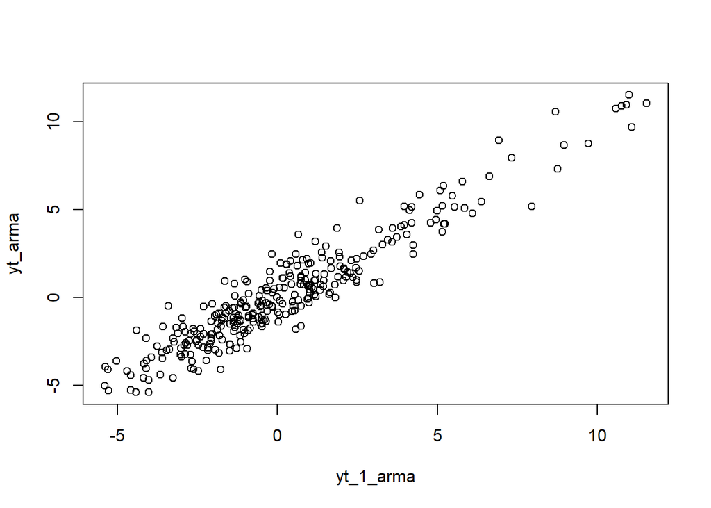

```r
plot(y=yt_arma,x=yt_1_arma)
```

Berdasarkan scatterplot tersebut, terlihat bahwa terdapat hubungan positif antara $Y_t$ dengan $Y_{t-1}$. Hal ini sesuai dengan teori yang ada

```r
cor(yt_arma,yt_1_arma)
```

```
## [1] 0.9473867
```

#### Korelasi antara $Y_t$ dengan $Y_{t-2}$

```r
#Yt
yt_arma <- arma22[-c(1,2)]
yt_arma
```

```
##   [1] -0.51316743 -1.48814639 -2.64080332 -1.77294378 -4.10664353 -2.30835364
##   [7] -2.07210051 -2.10576991 -2.60867516 -4.10466889 -4.02117765 -4.70254009
##  [13] -4.17109129 -3.75176475 -2.75891597 -2.46043339 -2.71835561 -3.26005567
##  [19] -2.31997178 -2.81365029 -2.70868924 -2.07201576 -2.45903041 -4.18289989
##  [25] -4.57960306 -5.27318496 -5.29462172 -4.08487753 -3.58932453 -3.45662430
##  [31] -3.01119092 -2.88365542 -3.22383439 -2.52384212 -2.40812407 -2.21284924
##  [37] -3.57211617 -1.65108173 -0.57078293  0.08162246 -0.17271902 -0.48688018
##  [43] -1.02547546 -2.04290860 -0.34999792 -1.33770310 -0.57636127 -1.11984465
##  [49] -0.35568185  0.53811772  0.15596001 -0.34924001 -0.31144524 -0.78124922
##  [55] -0.99065699 -0.55834126 -0.23633798  1.46719968  1.33944461  0.43675444
##  [61]  0.74553937  0.98344563 -0.30093911  0.40133532  1.20585533  0.05587147
##  [67]  0.56962921 -1.79877459 -2.17690021 -2.87028214 -2.59812939 -1.93069155
##  [73] -2.98493996 -1.16838663 -2.16797873 -2.99482835 -3.37696780 -2.94030386
##  [79] -1.64449801  0.94080974 -0.09521937  0.49272066 -0.47183859 -1.48570583
##  [85] -3.03450675 -3.25686950 -4.57939587 -4.42267436 -5.38205606 -3.94156189
```

[output cut: 35 more lines]

```r
#Yt-1
yt_2_arma <- arma22[-c(299,300)]
yt_2_arma
```

```
##   [1]  0.06081250 -0.95938218 -0.51316743 -1.48814639 -2.64080332 -1.77294378
##   [7] -4.10664353 -2.30835364 -2.07210051 -2.10576991 -2.60867516 -4.10466889
##  [13] -4.02117765 -4.70254009 -4.17109129 -3.75176475 -2.75891597 -2.46043339
##  [19] -2.71835561 -3.26005567 -2.31997178 -2.81365029 -2.70868924 -2.07201576
##  [25] -2.45903041 -4.18289989 -4.57960306 -5.27318496 -5.29462172 -4.08487753
##  [31] -3.58932453 -3.45662430 -3.01119092 -2.88365542 -3.22383439 -2.52384212
##  [37] -2.40812407 -2.21284924 -3.57211617 -1.65108173 -0.57078293  0.08162246
##  [43] -0.17271902 -0.48688018 -1.02547546 -2.04290860 -0.34999792 -1.33770310
##  [49] -0.57636127 -1.11984465 -0.35568185  0.53811772  0.15596001 -0.34924001
##  [55] -0.31144524 -0.78124922 -0.99065699 -0.55834126 -0.23633798  1.46719968
##  [61]  1.33944461  0.43675444  0.74553937  0.98344563 -0.30093911  0.40133532
##  [67]  1.20585533  0.05587147  0.56962921 -1.79877459 -2.17690021 -2.87028214
##  [73] -2.59812939 -1.93069155 -2.98493996 -1.16838663 -2.16797873 -2.99482835
##  [79] -3.37696780 -2.94030386 -1.64449801  0.94080974 -0.09521937  0.49272066
##  [85] -0.47183859 -1.48570583 -3.03450675 -3.25686950 -4.57939587 -4.42267436
```

[output cut: 35 more lines]

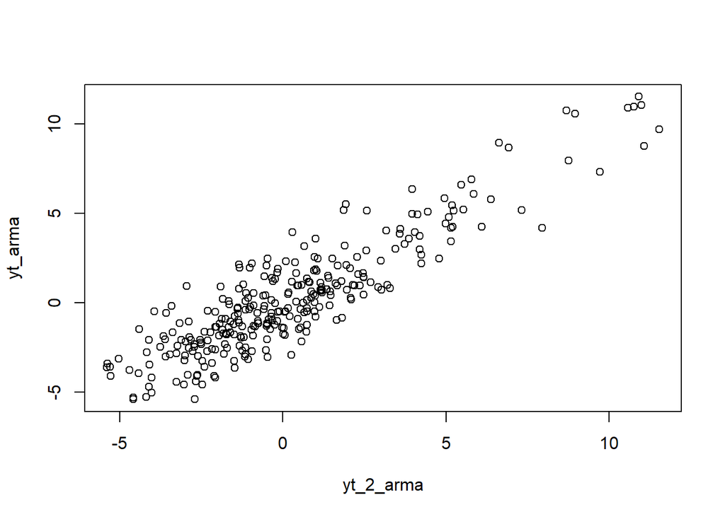

```r
plot(y=yt_arma,x=yt_2_arma)
```

```r
cor(yt_arma,yt_2_arma)
```

```
## [1] 0.8979138
```

#### Korelasi antara $Y_t$ dengan $Y_{t-3}$

```r
#Yt
yt_arma <- arma22[-c(1,2,3)]
yt_arma
```

```
##   [1] -1.48814639 -2.64080332 -1.77294378 -4.10664353 -2.30835364 -2.07210051
##   [7] -2.10576991 -2.60867516 -4.10466889 -4.02117765 -4.70254009 -4.17109129
##  [13] -3.75176475 -2.75891597 -2.46043339 -2.71835561 -3.26005567 -2.31997178
##  [19] -2.81365029 -2.70868924 -2.07201576 -2.45903041 -4.18289989 -4.57960306
##  [25] -5.27318496 -5.29462172 -4.08487753 -3.58932453 -3.45662430 -3.01119092
##  [31] -2.88365542 -3.22383439 -2.52384212 -2.40812407 -2.21284924 -3.57211617
##  [37] -1.65108173 -0.57078293  0.08162246 -0.17271902 -0.48688018 -1.02547546
##  [43] -2.04290860 -0.34999792 -1.33770310 -0.57636127 -1.11984465 -0.35568185
##  [49]  0.53811772  0.15596001 -0.34924001 -0.31144524 -0.78124922 -0.99065699
##  [55] -0.55834126 -0.23633798  1.46719968  1.33944461  0.43675444  0.74553937
##  [61]  0.98344563 -0.30093911  0.40133532  1.20585533  0.05587147  0.56962921
##  [67] -1.79877459 -2.17690021 -2.87028214 -2.59812939 -1.93069155 -2.98493996
##  [73] -1.16838663 -2.16797873 -2.99482835 -3.37696780 -2.94030386 -1.64449801
##  [79]  0.94080974 -0.09521937  0.49272066 -0.47183859 -1.48570583 -3.03450675
##  [85] -3.25686950 -4.57939587 -4.42267436 -5.38205606 -3.94156189 -3.41189607
```

[output cut: 35 more lines]

```r
#Yt-1
yt_3_arma <- arma22[-c(298,299,300)]
yt_3_arma
```

```
##   [1]  0.06081250 -0.95938218 -0.51316743 -1.48814639 -2.64080332 -1.77294378
##   [7] -4.10664353 -2.30835364 -2.07210051 -2.10576991 -2.60867516 -4.10466889
##  [13] -4.02117765 -4.70254009 -4.17109129 -3.75176475 -2.75891597 -2.46043339
##  [19] -2.71835561 -3.26005567 -2.31997178 -2.81365029 -2.70868924 -2.07201576
##  [25] -2.45903041 -4.18289989 -4.57960306 -5.27318496 -5.29462172 -4.08487753
##  [31] -3.58932453 -3.45662430 -3.01119092 -2.88365542 -3.22383439 -2.52384212
##  [37] -2.40812407 -2.21284924 -3.57211617 -1.65108173 -0.57078293  0.08162246
##  [43] -0.17271902 -0.48688018 -1.02547546 -2.04290860 -0.34999792 -1.33770310
##  [49] -0.57636127 -1.11984465 -0.35568185  0.53811772  0.15596001 -0.34924001
##  [55] -0.31144524 -0.78124922 -0.99065699 -0.55834126 -0.23633798  1.46719968
##  [61]  1.33944461  0.43675444  0.74553937  0.98344563 -0.30093911  0.40133532
##  [67]  1.20585533  0.05587147  0.56962921 -1.79877459 -2.17690021 -2.87028214
##  [73] -2.59812939 -1.93069155 -2.98493996 -1.16838663 -2.16797873 -2.99482835
##  [79] -3.37696780 -2.94030386 -1.64449801  0.94080974 -0.09521937  0.49272066
##  [85] -0.47183859 -1.48570583 -3.03450675 -3.25686950 -4.57939587 -4.42267436
```

[output cut: 35 more lines]

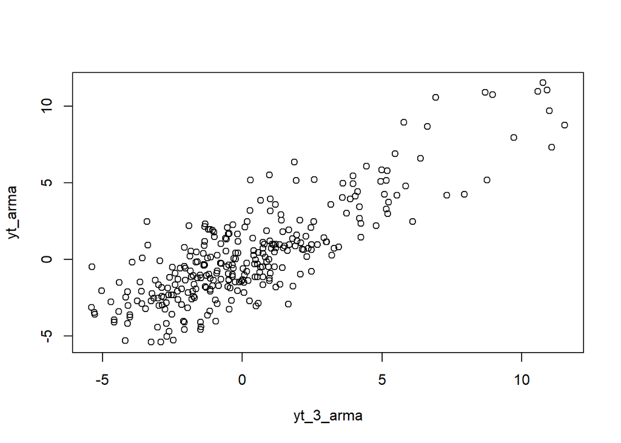

```r
plot(y=yt_arma,x=yt_3_arma)
```

```r
cor(yt_arma,yt_3_arma)
```

```
## [1] 0.8300275
```